# Group Name: Pi

Participants: Graham Bachman, Keith Hancock, Mallory Cotton-Witehorn, Sam Dean, Wei Qi, Nick Norris

Topic: Creating and Using a Neural Network to Predict AirBnB Prices in San Francisco, CA

Dataset comes from [http://insideairbnb.com/get-the-data.html], and for this project we looked at San Francisco, CA specifically.

# Pre-Processing and Exploratory Analysis

```python
# Importing required libraries
## Had to spend about an hour looking up how to install xgboost, kera (Mac OS Struggles)
import pandas as pd
import numpy as np
from numpy.random import seed
seed(1000)
import matplotlib.pyplot as plt
%matplotlib inline
from datetime import datetime
import seaborn as sns
from sklearn.preprocessing import StandardScaler, MinMaxScaler
from sklearn.model_selection import train_test_split, cross_val_score
!pip install xgboost
import xgboost as xgb
from xgboost import plot_importance
from sklearn.metrics import explained_variance_score, mean_squared_error, r2_score
import time
!pip install tensorflow as tf
!pip install keras
from keras import models, layers, optimizers, regularizers
from keras.utils.vis_utils import model_to_dot
from tensorflow.python.keras.utils.vis_utils import model_to_dot
from IPython.display import SVG
from statsmodels.tsa.seasonal import seasonal_decompose
```

```python
raw_df = pd.read_csv('listings.csv')
print(f"the dataset contatins {len(raw_df)} AirBnb Listings")
print(raw_df.shape)
pd.set_option('display.max_rows', None)
```

```
the dataset contatins 8572 AirBnb Listings
(8572, 106)
```

### Dropping initial columns

Dropping free-text columns because natural language processing is not relevant at this moment, and other columns not useful for price analysis (like host name, property name, etc.)

```python
cols_to_drop = ['listing_url', 'scrape_id', 'last_scraped', 'name', 'summary', 'space', 'description', 'neighborhood_overview', 'notes', 'transit', 'access', 'interaction', 'house_rules', 'thumbnail_url', 'medium_url', 'picture_url', 'xl_picture_url', 'host_id', 'host_url', 'host_name', 'host_location', 'host_about', 'host_thumbnail_url', 'host_picture_url', 'host_neighbourhood', 'host_verifications', 'calendar_last_scraped']
df = raw_df.drop(cols_to_drop, axis=1)
print(df.shape)
print(df.head(10))
```

```
(8572, 79)
      id experiences_offered host_since  host_response_time  \
0    958                none    7/31/08      within an hour
1   5858                none     3/2/09        within a day
2   7918                none    6/17/09      within an hour
3   8142                none    6/17/09      within an hour
4   8339                none     7/2/09        within a day
5   8739                none    1/27/09      within an hour
6   9225                none     8/4/09      within an hour
7  10251                none    8/31/09        within a day
8  10578                none     9/8/09        within a day
9  10820                none    9/15/09  within a few hours

  host_response_rate host_acceptance_rate host_is_superhost  \
0               100%                  99%                 t
```

[output cut: 83 more lines]

```python
#finding null entries
print(df.isna().sum())
```

```
id                                                 0
experiences_offered                                0
host_since                                         0
host_response_time                              1053
host_response_rate                              1053
host_acceptance_rate                             585
host_is_superhost                                  0
host_listings_count                                0
host_total_listings_count                          0
host_has_profile_pic                               0
host_identity_verified                             0
street                                             0
neighbourhood                                      1
neighbourhood_cleansed                             0
neighbourhood_group_cleansed                    8572
city                                               0
state                                              6
zipcode                                           23
market                                            18
smart_location                                     0
country_code                                       0
country                                            0
latitude                                           0
longitude                                          0
is_location_exact                                  0
property_type                                      0
room_type                                          0
accommodates                                       0
bathrooms                                          5
bedrooms                                           3
beds                                              30
bed_type                                           0
amenities                                          0
square_feet                                     8449
price                                              0
weekly_price                                    7556
monthly_price                                   7581
security_deposit                                1780
cleaning_fee                                     949
guests_included                                    0
```

[output cut: 25 more lines]

```
review_scores_value                             2058
requires_license                                   0
license                                         3392
jurisdiction_names                                40
instant_bookable                                   0
is_business_travel_ready                           0
cancellation_policy                                0
require_guest_profile_picture                      0
require_guest_phone_verification                   0
calculated_host_listings_count                     0
calculated_host_listings_count_entire_homes        0
calculated_host_listings_count_private_rooms       0
calculated_host_listings_count_shared_rooms        0
reviews_per_month                               1993
dtype: int64
```

```python
#drop columns with high null entries
df.drop(['host_acceptance_rate','neighbourhood_group_cleansed','square_feet','weekly_price','monthly_price','license'], axis=1, inplace=True)

# setting the 'id' column as the index
df.set_index('id', inplace=True)
```

host_listings_count and host_total_listings_count are the same in all cases, as shown below. These cases are those where the value is NaN. Therefore one of these columns can be dropped. Other columns which split these into type of property will also be dropped, as they will be highly correlated (one will be the total of the others).

```python
print(sum((df.host_listings_count == df.host_total_listings_count) == False))
df.loc[((df.host_listings_count == df.host_total_listings_count) == False)]
```

```
0
```

|  | experiences_offered | host_since | host_response_time | host_response_rate | host_is_superhost | host_listings_count | host_total_listings_count | host_has_profile_pic | host_identity_verified | street | ... | instant_bookable | is_business_travel_ready | cancellation_policy | require_guest_profile_picture | require_guest_phone_verification | calculated_host_listings_count | calculated_host_listings_count_entire_homes | calculated_host_listings_count_private_rooms | calculated_host_listings_count_shared_rooms | reviews_per_month |
| --- | --- | --- | --- | --- | --- | --- | --- | --- | --- | --- | --- | --- | --- | --- | --- | --- | --- | --- | --- | --- | --- |
| id |  |  |  |  |  |  |  |  |  |  |  |  |  |  |  |  |  |  |  |  |  |

0 rows × 72 columns

```python
df.drop(['host_total_listings_count', 'calculated_host_listings_count', 'calculated_host_listings_count_entire_homes', 'calculated_host_listings_count_private_rooms', 'calculated_host_listings_count_shared_rooms'], axis=1, inplace=True)
```

We'll also need to clean up the location-based columns, because all the listings are in San Francisco. There are also attempts from the data scraping process to 'clean up' neighbourhood locations. We won't keep any information on geographic location

```python
df.drop(['zipcode', 'latitude', 'longitude', 'street', 'neighbourhood', 'city', 'state', 'market', 'smart_location', 'country_code', 'country', 'is_location_exact', 'jurisdiction_names','neighbourhood_cleansed'], axis=1, inplace=True)
```

There are multiple columns for minimum and maximum night stays, but the two main ones will be used as there are few differences between e.g. minimum_nights and minimum_minimum_nights. The latter refers to the fact that min/max night stays can vary over the year. The default (i.e. most frequently applied) min/max night stay values will be used instead.

```python
sum((df.minimum_nights == df.minimum_minimum_nights) == False)
```

```
258
```

```python
df.drop(['minimum_minimum_nights', 'maximum_minimum_nights', 'minimum_maximum_nights', 'maximum_maximum_nights', 'minimum_nights_avg_ntm', 'maximum_nights_avg_ntm'], axis=1, inplace=True)
```

### Boolean (t/f) phrasing

Check boolean and categorical features to see if they're worth including in the analysis

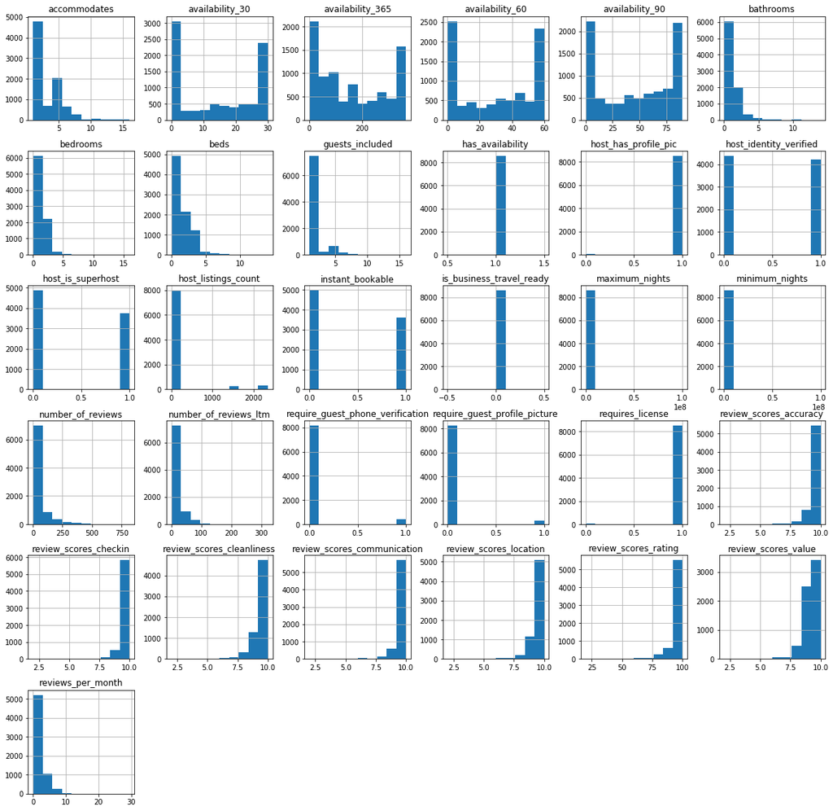

```python
# Replacing columns with (t or f) to (1 or 0)
df.replace({'f': 0, 't': 1}, inplace=True)

# Plotting the distribution of numerical and boolean categories
df.hist(figsize=(20,20));
```

From the above, it can be seen that several columns only contain one category, or a minute margin of difference, and can be dropped:

```python
df.drop(['has_availability', 'host_has_profile_pic','is_business_travel_ready','require_guest_phone_verification','require_guest_profile_picture','requires_license'], axis=1, inplace=True)
```

### Cleaning up individual columns

#### experiences_offered needs dropped

```python
df.drop(['experiences_offered'], axis=1, inplace=True)
```

#### host_since

This is a datetime column, and will be converted into a measure of the number of days that a host has been on the platform, measured from the date that the data was scraped (13 March 2020). The original column will be left in initially for EDA, and dropped later.

```python
# Converting to datetime
df.host_since = pd.to_datetime(df.host_since)

# Calculating the number of days
df['host_days_active'] = (datetime(2020, 3, 13) - df.host_since).astype('timedelta64[D]')

# Printing mean and median
print("Mean days as host:", round(df['host_days_active'].mean(),0))
print("Median days as host:", df['host_days_active'].median())

# Replacing null values with the median
df.host_days_active.fillna(df.host_days_active.median(), inplace=True)
```

```
Mean days as host: 1862.0
Median days as host: 1874.0
```

#### host_response_time

About an eighth of rows don't have a value for host_response_time, and the majority of these have also not yet been reviewed. Therefore this section of the dataset consists primarily of properties which have not yet had a completed stay (most likely properties which have not yet had a booking, although may also include properties that have a booking currently occuring). Although this is a considerable proportion of the dataset, these listings will be retained in the data because they are still legitimate properties with advertised prices, and are still part of the market when considering the price for which to advertise a listing. It is worth noting, however, that this group of listings probably also contains a large number of 'inactive' listings. These properties listed on AirBnB could be where hosts live in the property and are put at a high price to see if any guest owuld be willing to book, or 'inactive' listings, where the calendars are completely closed.

Because host_response_time is unknown for so many listings, it will be retained as its own category, 'unknown'.

```python
print("Null values:", df.host_response_time.isna().sum())
print(f"Proportion: {round((df.host_response_time.isna().sum()/len(df))*100, 1)}%")
```

```
Null values: 1053
Proportion: 12.3%
```

```python
df.host_response_time.fillna("unknown", inplace=True)
df.host_response_time.value_counts(normalize=True)
```

```
within an hour        0.622958
within a few hours    0.148973
unknown               0.122842
within a day          0.090411
a few days or more    0.014816
Name: host_response_time, dtype: float64
```

#### host_response_rate

A similar story is true for host_response_rate, with about an eighth of values being null. This will also be kept as its own category, after grouping other values into meaningful groups (i.e. transforming this into a categorical feature, rather than a numerical one). Because about 80% of hosts respond 100% of the time, this will be kept as its own category, and other values will be grouped into bins.

```python
print("Null values:", df.host_response_rate.isna().sum())
print(f"Proportion: {round((df.host_response_rate.isna().sum()/len(df))*100, 1)}%")
```

```
Null values: 1053
Proportion: 12.3%
```

```python
# Removing the % sign from the host_response_rate string and converting to an integer
df.host_response_rate = df.host_response_rate.str[:-1].astype('float64')

print("Mean host response rate:", round(df['host_response_rate'].mean(),0))
print("Median host response rate:", df['host_response_rate'].median())
print(f"Proportion of 100% host response rates: {round(((df.host_response_rate == 100.0).sum()/df.host_response_rate.count())*100,1)}%")
```

```
Mean host response rate: 96.0
Median host response rate: 100.0
Proportion of 100% host response rates: 78.2%
```

```python
# Bin into four categories
df.host_response_rate = pd.cut(df.host_response_rate, bins=[0, 50, 90, 99, 100], labels=['0-49%', '50-89%', '90-99%', '100%'], include_lowest=True)

# Converting to string
df.host_response_rate = df.host_response_rate.astype('str')

# Replace nulls with 'unknown'
df.host_response_rate.replace('nan', 'unknown', inplace=True)

# Category counts
df.host_response_rate.value_counts()
```

```
100%       5878
unknown    1053
50-89%      759
90-99%      659
0-49%       223
Name: host_response_rate, dtype: int64
```

#### property_type

Analysis and Processing of property types is required as there are a large number of categories with only a few listings. The categories 'apartment', 'house' and 'other' will be used, as most properties can be classified as either apartments or houses.

```python
df.property_type.value_counts()
```

```
Apartment                  3263
House                      2349
Condominium                 890
Guest suite                 595
Serviced apartment          400
Boutique hotel              336
Hotel                       167
Townhouse                   130
Loft                        105
Hostel                       77
Aparthotel                   67
Guesthouse                   48
Bed and breakfast            34
Other                        26
Cottage                      19
Resort                       16
Bungalow                     15
Villa                        12
Castle                        7
Tiny house                    5
Boat                          3
Cabin                         3
Earth house                   2
In-law                        1
Cycladic house (Greece)       1
Hut                           1
Name: property_type, dtype: int64
```

```python
# Replacing categories that are types of houses or apartments
df.property_type.replace({
    'Townhouse': 'House',
    'Serviced apartment': 'Apartment',
    'Loft': 'Apartment',
    'Bungalow': 'House',
    'Cottage': 'House',
    'Villa': 'House',
    'Tiny house': 'House',
    'Earth house': 'House',
    'Cabin': 'House',
    'Condominium': 'Apartment',
    'Guesthouse': 'House',
    }, inplace=True)

# Replacing other categories with 'other'
df.loc[~df.property_type.isin(['House', 'Apartment']), 'property_type'] = 'Other'
```

```python
df.property_type.value_counts()
```

```
Apartment    4658
House        2583
Other        1331
Name: property_type, dtype: int64
```

#### bathrooms, bedrooms, and beds

to avoid fractions, we're going to fill missing values in these categories with the median number respectively

```python
for col in ['bathrooms', 'bedrooms', 'beds']:
    df[col].fillna(df[col].median(), inplace=True)
```

#### bed_type

most listings have a similar bed type so this feature can be dropped.

```python
df.bed_type.value_counts()
```

```
Real Bed         8504
Futon              29
Pull-out Sofa      19
Airbed             12
Couch               8
Name: bed_type, dtype: int64
```

```python
df.drop('bed_type', axis=1, inplace=True)
```

#### amenities

Amenities is a list of additional features in the property, e.g. whether it has a TV or parking. Examples are below:

```python
# Example of amenities listed
df.amenities[:1].values
```

```
array(['{TV,"Cable TV",Internet,Wifi,Kitchen,"Pets live on this property",Dog(s),"Free street parking",Heating,"Family/kid friendly",Washer,Dryer,"Smoke detector","Carbon monoxide detector","First aid kit",Essentials,Shampoo,"24-hour check-in",Hangers,"Hair dryer",Iron,"Laptop friendly workspace","S…
      dtype=object)
```

```python
# Creating a set of all possible amenities
amenities_list = list(df.amenities)
amenities_list_string = " ".join(amenities_list)
amenities_list_string = amenities_list_string.replace('{', '')
amenities_list_string = amenities_list_string.replace('}', ',')
amenities_list_string = amenities_list_string.replace('"', '')
amenities_set = [x.strip() for x in amenities_list_string.split(',')]
amenities_set = set(amenities_set)
amenities_set
```

```
{'',
 '24-hour check-in',
 'Accessible-height bed',
 'Accessible-height toilet',
 'Air conditioning',
 'Air purifier',
 'Alarm system',
 'Amazon Echo',
 'Apple TV',
 'BBQ grill',
 'Baby bath',
 'Baby monitor',
 'Babysitter recommendations',
 'Baking sheet',
 'Balcony',
 'Barbecue utensils',
 'Bath towel',
 'Bathroom essentials',
 'Bathtub',
 'Bathtub with bath chair',
 'Beach essentials',
 'Beach view',
 'Beachfront',
 'Bed linens',
 'Bedroom comforts',
 'Bidet',
 'Body soap',
 'Bread maker',
 'Breakfast',
 'Breakfast bar',
 'Breakfast table',
 'Building staff',
 'Buzzer/wireless intercom',
 'Cable TV',
 'Carbon monoxide detector',
 'Cat(s)',
 'Ceiling fan',
 'Central air conditioning',
 'Changing table',
 'Children’s books and toys',
```

[output cut: 163 more lines]

```
 'Wet bar',
 'Wheelchair accessible',
 'Wide clearance to shower',
 'Wide doorway to guest bathroom',
 'Wide entrance',
 'Wide entrance for guests',
 'Wide entryway',
 'Wide hallways',
 'Wifi',
 'Window guards',
 'Wine cooler',
 'Wood-burning fireplace',
 'toilet',
 'translation missing: en.hosting_amenity_49',
 'translation missing: en.hosting_amenity_50'}
```

In the list above, some amenities are more important than others (a balcony is more likely to increase price than a fax machine), and some are likely to be fairly uncommon ('Electric profiling bed'). Based on some research for most important amenities from a similar topic done on AirBnB markets, a portion of the more important aminities will be extracted. These will be further investigated in the EDA section. For example, if it turns out that almost all properties have/do not have a particular amenity, that feature will not be very useful in helping explain differences in prices.

The amenities chosen are (slashes indicate separate categories that can be combined):

- 24-hour check-in
- Air conditioning/central air conditioning
- Amazon Echo/Apple TV/DVD player/game console/Netflix/projector and screen/smart TV (i.e. non-basic electronics)
- BBQ grill/fire pit/propane barbeque
- Balcony/patio or balcony
- Beach view/beachfront/lake access/mountain view/ski-in ski-out/waterfront (i.e. great location/views)
- Bed linens
- Breakfast
- Cable TV/TV
- Coffee maker/espresso machine
- Cooking basics
- Dishwasher/Dryer/Washer/Washer and dryer
- Elevator
- Exercise equipment/gym/private gym/shared gym
- Family/kid friendly, or anything containing 'children'
- Free parking on premises/free street parking/outdoor parking/paid parking off premises/paid parking on premises
- Garden or backyard/outdoor seating/sun loungers/terrace
- Host greets you
- Hot tub/jetted tub/private hot tub/sauna/shared hot tub/pool/private pool/shared pool
- Internet/pocket wifi/wifi
- Long term stays allowed
- Pets allowed/cat(s)/dog(s)/pets live on this property/other pet(s)
- Private entrance
- Safe/security system
- Self check-in
- Smoking allowed
- Step-free access/wheelchair accessible, or anything containing 'accessible'
- Suitable for events

```python
df.loc[df['amenities'].str.contains('24-hour check-in'), 'check_in_24h'] = 1
df.loc[df['amenities'].str.contains('Air conditioning|Central air conditioning'), 'air_conditioning'] = 1
df.loc[df['amenities'].str.contains('Amazon Echo|Apple TV|Game console|Netflix|Projector and screen|Smart TV'), 'high_end_electronics'] = 1
df.loc[df['amenities'].str.contains('BBQ grill|Fire pit|Propane barbeque'), 'bbq'] = 1
df.loc[df['amenities'].str.contains('Balcony|Patio'), 'balcony'] = 1
df.loc[df['amenities'].str.contains('Beach view|Beachfront|Lake access|Mountain view|Ski-in/Ski-out|Waterfront'), 'nature_and_views'] = 1
df.loc[df['amenities'].str.contains('Bed linens'), 'bed_linen'] = 1
df.loc[df['amenities'].str.contains('Breakfast'), 'breakfast'] = 1
df.loc[df['amenities'].str.contains('TV'), 'tv'] = 1
df.loc[df['amenities'].str.contains('Coffee maker|Espresso machine'), 'coffee_machine'] = 1
df.loc[df['amenities'].str.contains('Cooking basics'), 'cooking_basics'] = 1
df.loc[df['amenities'].str.contains('Dishwasher|Dryer|Washer'), 'white_goods'] = 1
df.loc[df['amenities'].str.contains('Elevator'), 'elevator'] = 1
df.loc[df['amenities'].str.contains('Exercise equipment|Gym|gym'), 'gym'] = 1
df.loc[df['amenities'].str.contains('Family/kid friendly|Children|children'), 'child_friendly'] = 1
df.loc[df['amenities'].str.contains('parking'), 'parking'] = 1
df.loc[df['amenities'].str.contains('Garden|Outdoor|Sun loungers|Terrace'), 'outdoor_space'] = 1
df.loc[df['amenities'].str.contains('Host greets you'), 'host_greeting'] = 1
df.loc[df['amenities'].str.contains('Hot tub|Jetted tub|hot tub|Sauna|Pool|pool'), 'hot_tub_sauna_or_pool'] = 1
df.loc[df['amenities'].str.contains('Internet|Pocket wifi|Wifi'), 'internet'] = 1
df.loc[df['amenities'].str.contains('Long term stays allowed'), 'long_term_stays'] = 1
df.loc[df['amenities'].str.contains('Pets|pet|Cat(s)|Dog(s)'), 'pets_allowed'] = 1
df.loc[df['amenities'].str.contains('Private entrance'), 'private_entrance'] = 1
df.loc[df['amenities'].str.contains('Safe|Security system'), 'secure'] = 1
df.loc[df['amenities'].str.contains('Self check-in'), 'self_check_in'] = 1
df.loc[df['amenities'].str.contains('Smoking allowed'), 'smoking_allowed'] = 1
df.loc[df['amenities'].str.contains('Step-free access|Wheelchair|Accessible'), 'accessible'] = 1
df.loc[df['amenities'].str.contains('Suitable for events'), 'event_suitable'] = 1
```

```python
# Replacing nulls with zeros for new columns
cols_to_replace_nulls = df.iloc[:,41:].columns
df[cols_to_replace_nulls] = df[cols_to_replace_nulls].fillna(0)

# Produces a list of amenity features where one category (true or false) contains fewer than 10% of listings
infrequent_amenities = []
for col in df.iloc[:,41:].columns:
    if df[col].sum() < len(df)/10:
        infrequent_amenities.append(col)
print(infrequent_amenities)

# Dropping infrequent amenity features
df.drop(infrequent_amenities, axis=1, inplace=True)

# Dropping the original amenity feature
df.drop('amenities', axis=1, inplace=True)
```

```
['high_end_electronics', 'nature_and_views', 'host_greeting', 'hot_tub_sauna_or_pool', 'smoking_allowed', 'accessible', 'event_suitable']
```

```python
df.columns[41:]
```

```
Index(['bbq', 'balcony', 'bed_linen', 'breakfast', 'tv', 'coffee_machine',
       'cooking_basics', 'white_goods', 'elevator', 'gym', 'child_friendly',
       'parking', 'outdoor_space', 'internet', 'long_term_stays',
       'pets_allowed', 'private_entrance', 'secure', 'self_check_in'],
      dtype='object')
```

#### price, security_deposit, cleaning_fee, and extra_people

These variables need to be converted to an integer from a string, because there are dollar signs

If values are null (0), then they will be replaced with the integer 0 because it's essentially a $0 value for the respective fee

```python
#price
df.price = df.price.str.replace('[\$\,]|\.\d*', '').astype(float)
#security_deposit
df.security_deposit = df.security_deposit.str[1:-3]
df.security_deposit = df.security_deposit.str.replace(",", "")
df.security_deposit.fillna(0, inplace=True)
df.security_deposit = df.security_deposit.astype(float)
#cleaning_fee
df.cleaning_fee = df.cleaning_fee.str[1:-3]
df.cleaning_fee = df.cleaning_fee.str.replace(",", "")
df.cleaning_fee.fillna(0, inplace=True)
df.cleaning_fee = df.cleaning_fee.astype(float)
#extra_people
df.extra_people = df.extra_people.str[1:-3]
df.extra_people = df.extra_people.str.replace(",", "")
df.extra_people.fillna(0, inplace=True)
df.extra_people = df.extra_people.astype(float)
```

#### calendar_updated

```python
print("Number of categories:", df.calendar_updated.nunique())
```

```
Number of categories: 68
```

We are going to drop the 'calendar_updated' column because it's unclear as to what this variable adds to the model. There could be multiple reasons as to why a host would update their calendar

```python
df.drop('calendar_updated', axis=1, inplace=True)
```

#### availability

In San Francisco, Under existing law, anyone in the City of San Francisco listing a residential property for short-term rent (less than 30 nights at a time) on a hosting platform like Airbnb must register for a Short-Term Residential Rental Certificate and Business Registration Certificate. Because of this, we will only keep the availability_30 variable for this model.

```python
df.drop(['availability_60', 'availability_90', 'availability_365'], axis=1, inplace=True)
```

#### first_review and last_review

About a quarter of listings (~24%) have not had a review written for them. This is too large a proportion of the dataset to drop, and dropping the columns would lose a lot of useful information - reviews are very important in people's decisions to book, and that could affect overall price.

This is too large a proportion of the dataset to replace with median/mean values, because it would skew the distribution. The missing values here are not really missing values; it tells us that these are new or previously unbooked listings that have not had reviews yet. To make the resulting model work able to predict prices for any Airbnb listing, including brand new listings, it's beneficial to keep them in.

These will be kept as an 'unknown' category, and the feature will have to be treated as categorical, and will be 'one-hot' encoded.

Below is a distribution of the number of days since the first review.

```python
print(f"Null values in 'first_review': {round(100*df.first_review.isna().sum()/len(df),1)}%")
print(f"Null values in 'review_scores_rating': {round(100*df.review_scores_rating .isna().sum()/len(df),1)}%")
```

```
Null values in 'first_review': 23.3%
Null values in 'review_scores_rating': 23.9%
```

```python
# Converting to datetime
df.first_review = pd.to_datetime(df.first_review)

# Calculating the number of days between the first review and the date the data was scraped
df['time_since_first_review'] = (datetime(2020, 3, 13) - df.first_review).astype('timedelta64[D]')
```

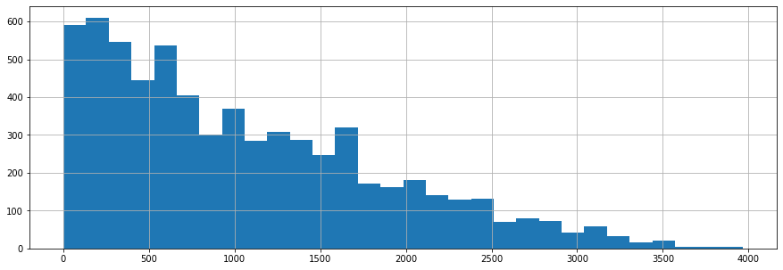

```python
# Distribution of the number of days since first review
df.time_since_first_review.hist(figsize=(15,5), bins=30)
```

We will create a function to bin the columns of first and last reviews into appropriate time spans (0-6 months, 6-12 months, 1-2 years, 2-3 years, 4+ years)

We will end up dropping the last_review because of the distribution. first_review will be kept for later analysis.

```python
def bincolumn(col, bins, labels, na_label='unknown'):
    """
    Takes in a column name, bin cut points and labels, replaces the original column with a
    binned version, and replaces nulls with 'unknown' if there's no specific value.
    """
    df[col] = pd.cut(df[col], bins=bins, labels=labels, include_lowest=True)
    df[col] = df[col].astype('str')
    df[col].fillna(na_label, inplace=True)
```

```python
# Binning time since first review
bincolumn('time_since_first_review',
           bins=[0, 182, 365, 730, 1460, max(df.time_since_first_review)],
           labels=['0-6 months',
                   '6-12 months',
                   '1-2 years',
                   '2-3 years',
                   '4+ years'],
           na_label='no reviews')
```

```python
# Converting to datetime
df.last_review = pd.to_datetime(df.last_review)

# Calculating the number of days between the most recent review and the date the data was scraped
df['time_since_last_review'] = (datetime(2020, 3, 13) - df.last_review).astype('timedelta64[D]')
```

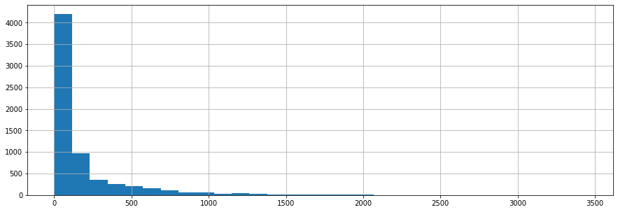

```python
# Distribution of the number of days since last review
df.time_since_last_review.hist(figsize=(15,5), bins=30)
```

```python
df.last_review = pd.to_datetime(df.last_review) # Converting to datetime

# Calculating the number of days between the most recent review and the date the data was scraped
df['time_since_last_review'] = (datetime(2020, 3, 13) - df.last_review).astype('timedelta64[D]')
```

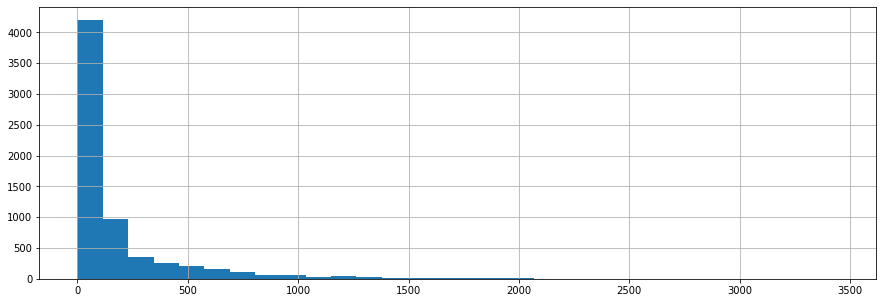

```python
# Distribution of the number of days since last review
df.time_since_last_review.hist(figsize=(15,5), bins=30);
```

```python
# Binning time since last review
bincolumn('time_since_last_review',
           bins=[0, 14, 60, 182, 365, max(df.time_since_last_review)],
           labels=['0-2 weeks',
                   '2-8 weeks',
                   '2-6 months',
                   '6-12 months',
                   '1+ year'],
           na_label='no reviews')
```

```python
# Dropping last_review
df.drop('last_review', axis=1, inplace=True)
```

#### review ratings columns

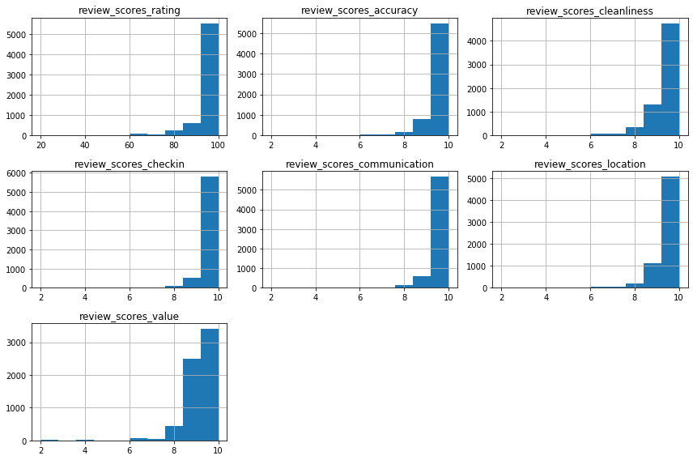

```python
# Checking the distributions of the review ratings columns
variables_to_plot = list(df.columns[df.columns.str.startswith("review_scores") == True])
fig = plt.figure(figsize=(12,8))
for i, var_name in enumerate(variables_to_plot):
    ax = fig.add_subplot(3,3,i+1)
    df[var_name].hist(bins=10,ax=ax)
    ax.set_title(var_name)
fig.tight_layout()
plt.show()
```

```python
# Creating a list of all review columns that are scored out of 10
variables_to_plot.pop(0)
```

```
'review_scores_rating'
```

```python
# Binning for all columns scored out of 10
for col in variables_to_plot:
    bincolumn(col,
               bins=[0, 8, 9, 10],
               labels=['0-8/10', '9/10', '10/10'],
               na_label='no reviews')
```

```python
bincolumn('review_scores_rating',
           bins=[0, 80, 95, 100],
           labels=['0-79/100', '80-94/100', '95-100/100'],
           na_label='no reviews')
```

#### cancellation_policy

We need to clean up the cancellation_policy variable in order to categorize the categories into the three larger categories (the super strict options are only available to long-term Airbnb hosts, and is invitation only).

```python
df.cancellation_policy.value_counts()
```

```
strict_14_with_grace_period    3883
moderate                       2577
flexible                       1927
strict                          114
super_strict_30                  46
super_strict_60                  18
luxury_moderate                   7
Name: cancellation_policy, dtype: int64
```

```python
# Replacing categories
df.cancellation_policy.replace({
    'super_strict_30': 'strict_14_with_grace_period',
    'super_strict_60': 'strict_14_with_grace_period',
    'strict': 'strict_14_with_grace_period',
    'luxury_moderate': 'moderate'
    }, inplace=True)
```

#### number_of_reviews_ltm and reviews_per_month

These will end up correlated with number_of_reviews and will be dropped.

```python
df.drop(['number_of_reviews_ltm', 'reviews_per_month'], axis=1, inplace=True)
```

# Exporatory Data Analysis

### Time series

The oldest San Francisco listing that is currently live on Airbnb was first listed on the site in March 2008. From 2011 onwards, the number of listings started increasing considerably. However, growth in the number of new hosts (of those currently listing on the site) has been decreasing since 2017, likely because of the Pass-Through Registration (PTR) system that asks for hosts to apply for a Short-Term Residential Rental Certificate and Business Registration Certificate.

```python
print(f"Of the Airbnb hosts that are still listing on the site, the first joined on {min(df.host_since).strftime('%d %B %Y')}, and the most recent joined on {max(df.host_since).strftime('%d %B %Y')}.")
```

```
Of the Airbnb hosts that are still listing on the site, the first joined on 03 March 2008, and the most recent joined on 10 March 2020.
```

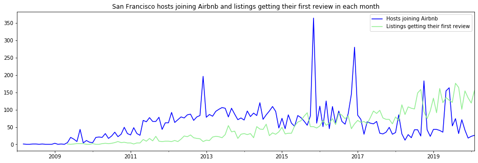

```python
plt.figure(figsize=(16,5))
df.set_index('host_since').resample('MS').size().plot(label='Hosts joining Airbnb', color='blue')
df.set_index('first_review').resample('MS').size().plot(label='Listings getting their first review', color='lightgreen')
plt.title('San Francisco hosts joining Airbnb and listings getting their first review in each month')
plt.legend()
plt.xlim('2008-01-01', '2020-02-01') # Limiting to whole months
plt.xlabel('')
plt.ylabel('')
plt.show()
```

```python
# Creating dataframes for time series analysis
ts_host_since = pd.DataFrame(df.set_index('host_since').resample('MS').size())
ts_first_review = pd.DataFrame(df.set_index('first_review').resample('MS').size())

# Renaming columns
ts_host_since = ts_host_since.rename(columns={0: 'hosts'})
ts_host_since.index.rename('month', inplace=True)
ts_first_review = ts_first_review.rename(columns={0: 'reviews'})
ts_first_review.index.rename('month', inplace=True)
```

```python
# define functoin for decomposition of time in the series for trend, seasonal, and residual analysis.
def decompose_time(df, title=''):
    """
    Plots the original time series and its decomposition into trend, seasonal and residual.
    """
    # Decomposing the time series
    decomposition = seasonal_decompose(df)

    # Getting the trend, seasonality and noise
    trend = decomposition.trend
    seasonal = decomposition.seasonal
    residual = decomposition.resid

    # Plotting the original time series and the decomposition
    plt.figure(figsize=(12,8))
    plt.suptitle(title, fontsize=14, y=1)
    plt.subplots_adjust(top=0.80)
    plt.subplot(411)
    plt.plot(df, label='Original')
    plt.legend(loc='upper left')
    plt.subplot(412)
    plt.plot(trend, label='Trend')
    plt.legend(loc='upper left')
    plt.subplot(413)
    plt.plot(seasonal,label='Seasonality')
    plt.legend(loc='upper left')
    plt.subplot(414)
    plt.plot(residual, label='Residuals')
    plt.legend(loc='upper left')
    plt.tight_layout()
```

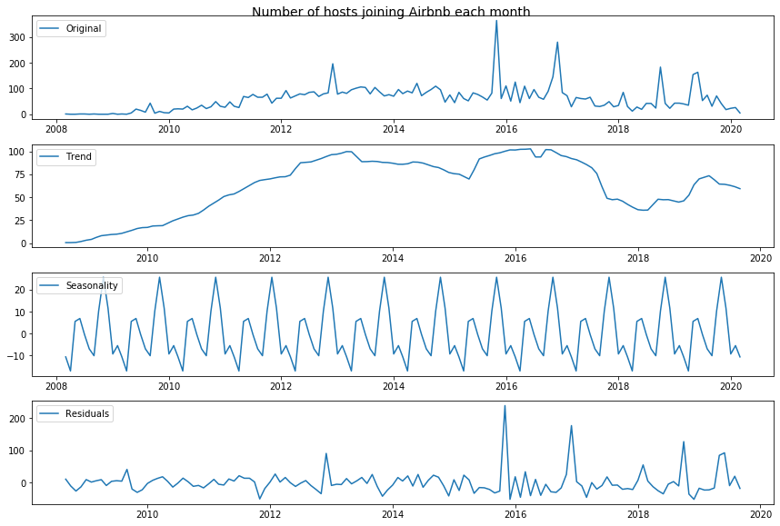

```python
decompose_time(ts_host_since, title='Number of hosts joining Airbnb each month')
```

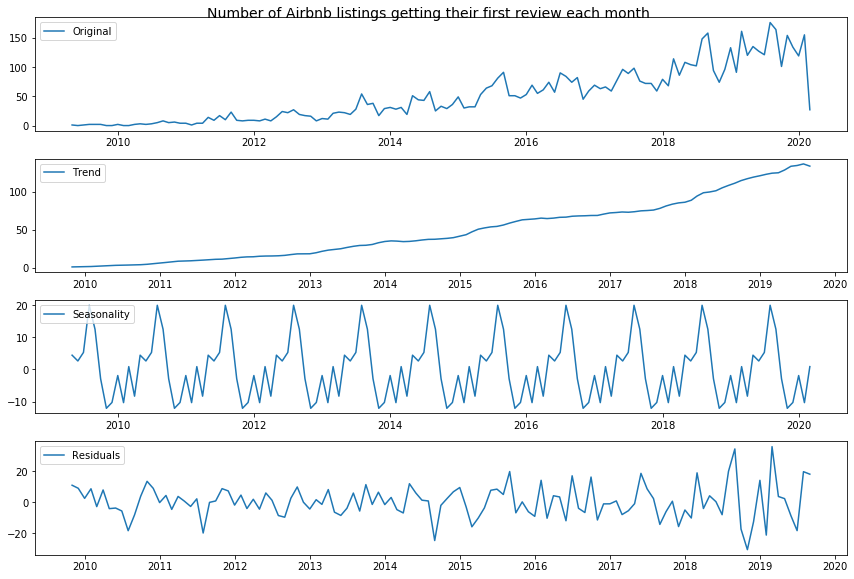

```python
decompose_time(ts_first_review, title='Number of Airbnb listings getting their first review each month')
```

### Mass-Hosting

There are increasing numbers of professional Airbnb management companies that host a large number of listings under a single host profile, particularly from 2015 onwards.

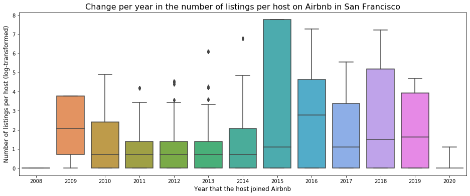

```python
plt.figure(figsize=(16,6))
sns.boxplot(df.host_since.dt.year, np.log(df.host_listings_count))
plt.xlabel('Year that the host joined Airbnb', fontsize=12)
plt.ylabel('Number of listings per host (log-transformed)', fontsize=12)
plt.title('Change per year in the number of listings per host on Airbnb in San Francisco', fontsize=16)
plt.show()
```

```python
print("Average number of listings per host per year on Airbnb in San Francisco:")
print(round(df.set_index('host_since').host_listings_count.resample('YS').mean(),2))
```

```
Average number of listings per host per year on Airbnb in San Francisco:
host_since
2008-01-01      1.00
2009-01-01     18.25
2010-01-01     12.25
2011-01-01      5.73
2012-01-01     13.05
2013-01-01     10.86
2014-01-01     15.57
2015-01-01    661.23
2016-01-01    317.21
2017-01-01     21.62
2018-01-01     61.55
2019-01-01     23.51
2020-01-01      0.52
Freq: AS-JAN, Name: host_listings_count, dtype: float64
```

```python
# List of the largest host_listings_count and the year the host joined Airbnb
df.sort_values('host_listings_count').drop_duplicates('host_listings_count',keep='last').tail(10)[['host_since', 'host_listings_count']]
```

| id | host_since | host_listings_count |
| --- | --- | --- |
| 13811042 | 2010-04-04 | 135 |
| 32525042 | 2018-10-10 | 180 |
| 31188284 | 2016-10-18 | 221 |
| 23452479 | 2017-04-19 | 254 |
| 28073566 | 2013-10-14 | 440 |
| 14246713 | 2015-03-30 | 684 |
| 20426652 | 2014-02-14 | 883 |
| 32105198 | 2018-06-11 | 1364 |
| 29000480 | 2016-12-16 | 1437 |
| 21783775 | 2015-11-02 | 2345 |

### Price Changes

The average price per night for Airbnb listings in San Francisco has increased minimally over the last 11 years. In particular, the top end of property prices has increased, resulting in a larger increase in the mean price compared to the median.

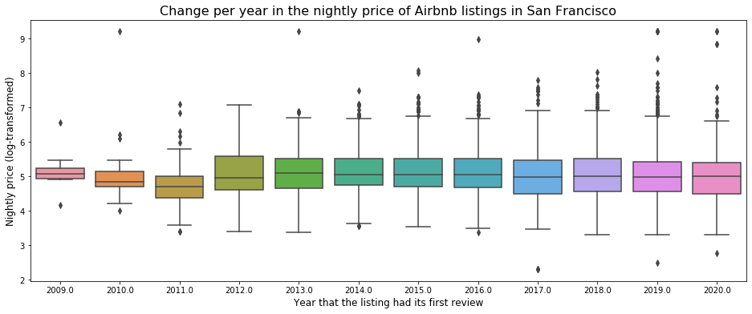

```python
plt.figure(figsize=(16,6))
sns.boxplot(df.first_review.dt.year, np.log(df.price))
plt.xlabel('Year that the listing had its first review', fontsize=12)
plt.ylabel('Nightly price (log-transformed)', fontsize=12)
plt.title('Change per year in the nightly price of Airbnb listings in San Francisco', fontsize=16)
plt.show()
```

```python
print("Mean nightly price of listings in each year on Airbnb in San Francisco:")
print(round(df.set_index('first_review').price.resample('YS').mean(),2))
```

```
Mean nightly price of listings in each year on Airbnb in San Francisco:
first_review
2009-01-01    223.12
2010-01-01    396.72
2011-01-01    148.17
2012-01-01    209.88
2013-01-01    240.04
2014-01-01    215.87
2015-01-01    232.06
2016-01-01    227.43
2017-01-01    201.21
2018-01-01    209.67
2019-01-01    237.26
2020-01-01    310.33
Name: price, dtype: float64
```

```python
# Dropping host_since and first_review as they are no longer needed
df.drop(['host_since', 'first_review'], axis=1, inplace=True)
```

### Numerical Features

```python
df.describe()
```

|  | host_is_superhost | host_listings_count | host_identity_verified | accommodates | bathrooms | bedrooms | beds | price | security_deposit | cleaning_fee | ... | gym | child_friendly | parking | outdoor_space | internet | long_term_stays | pets_allowed | private_entrance | secure | self_check_in |
| --- | --- | --- | --- | --- | --- | --- | --- | --- | --- | --- | --- | --- | --- | --- | --- | --- | --- | --- | --- | --- | --- |
| count | 8572.000000 | 8572.000000 | 8572.000000 | 8572.000000 | 8572.000000 | 8572.000000 | 8572.000000 | 8572.000000 | 8572.000000 | 8572.000000 | ... | 8572.000000 | 8572.000000 | 8572.000000 | 8572.000000 | 8572.000000 | 8572.000000 | 8572.000000 | 8572.000000 | 8572.000000 | 8572.000000 |
| mean | 0.434438 | 144.744517 | 0.490201 | 3.106043 | 1.406265 | 1.323728 | 1.707769 | 227.820929 | 352.751750 | 101.060079 | ... | 0.141974 | 0.328745 | 0.633691 | 0.253383 | 0.984951 | 0.314512 | 0.214069 | 0.427322 | 0.141157 | 0.490201 |
| std | 0.495712 | 487.268229 | 0.499933 | 1.895983 | 0.949607 | 0.928091 | 1.189489 | 457.656486 | 696.330685 | 97.297035 | ... | 0.349044 | 0.469784 | 0.481823 | 0.434974 | 0.121755 | 0.464348 | 0.410199 | 0.494718 | 0.348204 | 0.499933 |
| min | 0.000000 | 0.000000 | 0.000000 | 1.000000 | 0.000000 | 0.000000 | 0.000000 | 0.000000 | 0.000000 | 0.000000 | ... | 0.000000 | 0.000000 | 0.000000 | 0.000000 | 0.000000 | 0.000000 | 0.000000 | 0.000000 | 0.000000 | 0.000000 |
| 25% | 0.000000 | 1.000000 | 0.000000 | 2.000000 | 1.000000 | 1.000000 | 1.000000 | 99.000000 | 0.000000 | 30.000000 | ... | 0.000000 | 0.000000 | 0.000000 | 0.000000 | 1.000000 | 0.000000 | 0.000000 | 0.000000 | 0.000000 | 0.000000 |
| 50% | 0.000000 | 3.000000 | 0.000000 | 2.000000 | 1.000000 | 1.000000 | 1.000000 | 150.000000 | 100.000000 | 80.000000 | ... | 0.000000 | 0.000000 | 1.000000 | 0.000000 | 1.000000 | 0.000000 | 0.000000 | 0.000000 | 0.000000 | 0.000000 |
| 75% | 1.000000 | 18.000000 | 1.000000 | 4.000000 | 1.500000 | 2.000000 | 2.000000 | 240.000000 | 500.000000 | 150.000000 | ... | 0.000000 | 1.000000 | 1.000000 | 1.000000 | 1.000000 | 1.000000 | 0.000000 | 1.000000 | 0.000000 | 1.000000 |
| max | 1.000000 | 2345.000000 | 1.000000 | 16.000000 | 14.000000 | 16.000000 | 14.000000 | 10000.000000 | 5100.000000 | 1350.000000 | ... | 1.000000 | 1.000000 | 1.000000 | 1.000000 | 1.000000 | 1.000000 | 1.000000 | 1.000000 | 1.000000 | 1.000000 |

8 rows × 39 columns

#### Price

Price can range from 0 to 10,000 dollars per night in San Francisco. The extreme end of this distribution could be due to hosts not knowing how to use AirBnB-advertised prices (sticker prices). The prices themselves can be set to any arbitrary amount, and these are the prices that show when dates are not on the site. (think about if you've been on Craigslist, Facebook Marketplace, or a similar buy/sell platform, and the actual price is in the details of a listing, instead of the advertised price)

Unfortunately this model will be predicting advertised prices rather than the prices actually paid. Nevertheless, some cleaning of the particularly unhelpful values will be done. Very small values under 10 will be increased to 10.

There are notable drop-offs in nightly prices at around 200 (first graph, orange line), 300 (second graph, orange line) and 1,100 (second graph, red line). Values above 1,500 will be reduced to 1,500.

```python
print(f"Nightly advertised prices range from ${min(df.price)} to ${max(df.price)}.")
```

```
Nightly advertised prices range from $0.0 to $10000.0.
```

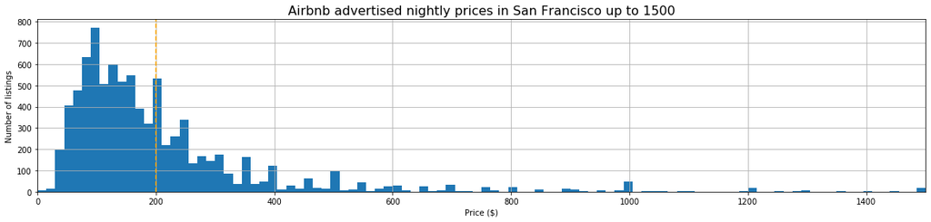

```python
# Distribution of prices from 0 to 1500
plt.figure(figsize=(20,4))
df.price.hist(bins=100, range=(0,1500))
plt.margins(x=0)
plt.axvline(200, color='orange', linestyle='--')
plt.title("Airbnb advertised nightly prices in San Francisco up to 1500", fontsize=16)
plt.xlabel("Price ($)")
plt.ylabel("Number of listings")
plt.show()
```

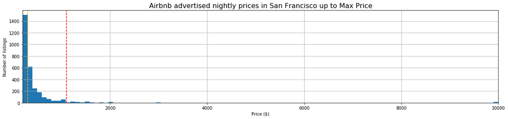

```python
# Distribution of prices from $200 upwards
plt.figure(figsize=(20,4))
df.price.hist(bins=100, range=(200, max(df.price)))
plt.margins(x=0)
plt.axvline(300, color='orange', linestyle='--')
plt.axvline(1100, color='red', linestyle='--')
plt.title("Airbnb advertised nightly prices in San Francisco up to Max Price", fontsize=16)
plt.xlabel("Price ($)")
plt.ylabel("Number of listings")
plt.show()
```

```python
# Replacing values under $10 with $10
df.loc[df.price <= 10, 'price'] = 10

# Replacing values over $1000 with $1000
df.loc[df.price >= 1500, 'price'] = 1500
```

#### host listings count

The median number of listings that the host of each listing has is 3. The mean is much, much higher (145) due to some hosts managing large numbers of listings (as discussed above in the Time Series section).

Two difficulties in discerning how many listings hosts have on average are:

- this number is only known on the level of the listing, so hosts with more listings are represented more frequently (host with 10 listings may be represented up to 10 times in the dataset)
- a host's other listings may not be in San Francisco so some multi-listing hosts may appear multiple times in the dataset, and others may appear only once

```python
print("Median number of listings per host:", int(df.host_listings_count.median()))
print("Mean number of listings per host:", int(round(df.host_listings_count.mean())))
print(f"{int(round(100*len(df[df.host_listings_count == 1])/len(df)))}% of listings are from hosts with one listing.")
```

```
Median number of listings per host: 3
Mean number of listings per host: 145
29% of listings are from hosts with one listing.
```

#### Persons accommodated, bathrooms, bedrooms and beds

The most common property setup sleeps two people in one bed in one bedroom, with one bathroom. Unsurprisingly, properties that accommodate more people achieve noticeably higher nightly rates, with diminishing returns coming after about 8-10 people. Overall though, price fluctuates greatly after 8 people. (15-person accomodation has a similar price to 8 people, for example)

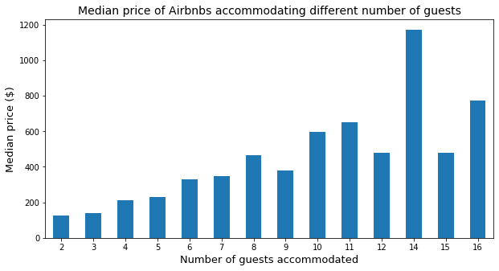

```python
plt.figure(figsize=(10,5))
df.groupby('accommodates').price.median().plot(kind='bar')
plt.title('Median price of Airbnbs accommodating different number of guests', fontsize=14)
plt.xlabel('Number of guests accommodated', fontsize=13)
plt.ylabel('Median price ($)', fontsize=13)
plt.xticks(rotation=0)
plt.xlim(left=0.5)
plt.show()
```

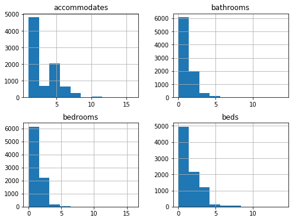

```python
df[['accommodates', 'bathrooms', 'bedrooms', 'beds']].hist(figsize=(8,6));
```

### Categorical Features

Categorical features will be explored and plotted to gain insight and determine whether or not they should be included in the final model.

#### Property and Room Types

About 60% of listings are entire homes (renting the entire property on your own). Most of the remainder are private rooms (renting a bedroom and possibly also a bathroom, but there will be other people in the property). the remaining 4% are shared rooms or hotel rooms(sharing a room with either the property owner or other guests, or an AirBnB listing for a hotel room).

```python
def category_count(col, figsize=(8,4)):
    """
    Plots a simple bar chart of the total count for each category in the column specified.
    A figure size can optionally be specified.
    """
    plt.figure(figsize=figsize)
    df[col].value_counts().plot(kind='bar')
    plt.title(col)
    plt.xticks(rotation=45)
    plt.show()
```

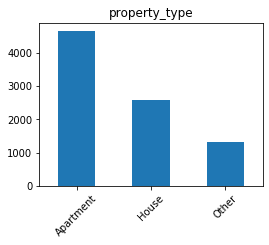

```
Apartment    0.543397
House        0.301330
Other        0.155273
Name: property_type, dtype: float64
```

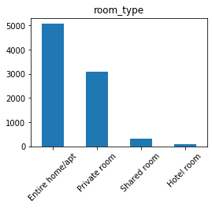

```
Entire home/apt    0.590877
Private room       0.360943
Shared room        0.036514
Hotel room         0.011666
Name: room_type, dtype: float64
```

```python
for col in ['property_type', 'room_type']:
    category_count(col, figsize=(4,3))
    print(df[col].value_counts(normalize=True))
```

#### Reviews

for every review category, the majority of listings that have had a review have received a 10/10 rating for that category (or 95-100/100 overall). Ratings of 8 or below are few and far between.

Guests seem to be most positive about communication, check-ins and accuracy. There's a considerable number of listings that have not been reviewed as well.

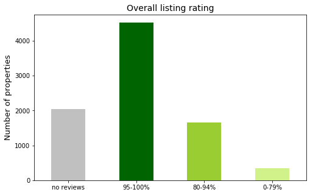

```python
fig, ax = plt.subplots(1, 1, figsize=(8,5))
ax.set_title('Overall listing rating', fontsize=14)
df['review_scores_rating'].value_counts().sort_index(ascending=False).plot(kind='bar', color=['silver', 'darkgreen', 'yellowgreen', '#d1f28a' ], ax=ax)
ax.set_xticklabels(labels=['no reviews', '95-100%', '80-94%', '0-79%'], rotation=0)
ax.set_xlabel('')
ax.set_ylabel('Number of properties', fontsize=13)
plt.show()
```

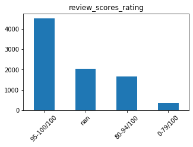

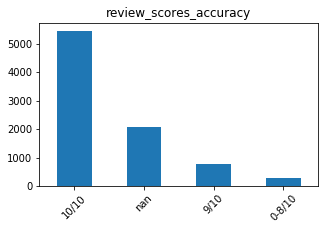

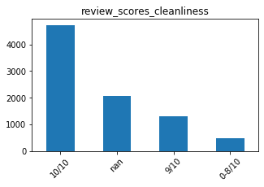

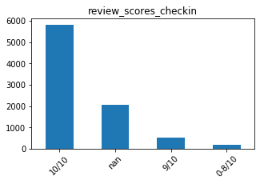

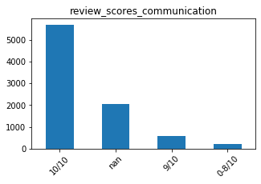

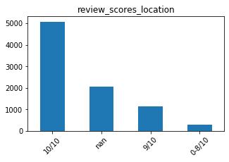

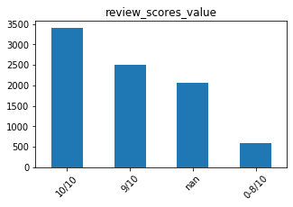

```python
for col in list(df.columns[df.columns.str.startswith("review_scores") == True]):
    category_count(col, figsize=(5,3))
```

#### First and last reviews

the most frequent time period in which live AirBnB listings had their first review is 4+ years, and close to that is 2-3 years. This means that a lot of listings on the site have been active for at least 4 years. Relatively few have been active for less than 6 months.

The most common category for the time since a listing received its last review is 2-8 weeks. This means that a lot of listings have been reviewed relatively recently.

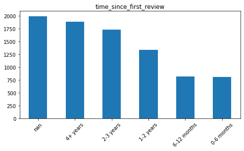

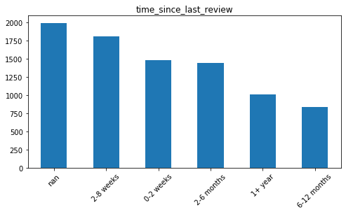

```python
for col in ['time_since_first_review', 'time_since_last_review']:
    category_count(col)
```

### Boolean (t/f) Features

Features can be true or false. This portion compares the proportions of these features that are true or false (to explore the data and also to ascertain whether the feature is worth retaining), and the median price of each category (to explore the relationship between the category and price).

```python
# define function for a bar chart to count t/f categories in the specified column,
# displayed next to a bar chart of the median price for each category

def binary_count_price_plot(col, figsize=(8,3)):

    fig, (ax1, ax2) = plt.subplots(1, 2, figsize=figsize)
    fig.suptitle(col, fontsize=16, y=1)
    plt.subplots_adjust(top=0.80) # So that the suptitle does not overlap with the ax plot titles

    df.groupby(col).size().plot(kind='bar', ax=ax1, color=['red', 'lightblue'])
    ax1.set_xticklabels(labels=['false', 'true'], rotation=0)
    ax1.set_title('Category count')
    ax1.set_xlabel('')

    df.groupby(col).price.median().plot(kind='bar', ax=ax2, color=['red', 'lightblue'])
    ax2.set_xticklabels(labels=['false', 'true'], rotation=0)
    ax2.set_title('Median price ($)')
    ax2.set_xlabel('')

    plt.show()
```

#### Superhosts

about 43% of hosts are superhosts. It seems it might slightly improve the median price per night of their Airbnb listings, so it is arguable whether or not it is worth it in a financial perspective.

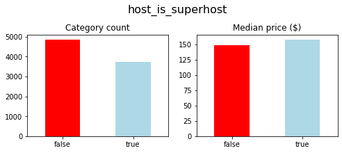

```
0    0.565562
1    0.434438
Name: host_is_superhost, dtype: float64
```

```python
binary_count_price_plot('host_is_superhost')
print(df.host_is_superhost.value_counts(normalize=True))
```

#### Host verification

It seems that it's an even split between verified and non-verified hosts (verifications: ID, phone number, email address).

```python
df.host_identity_verified.value_counts(normalize=True)
```

```
0    0.509799
1    0.490201
Name: host_identity_verified, dtype: float64
```

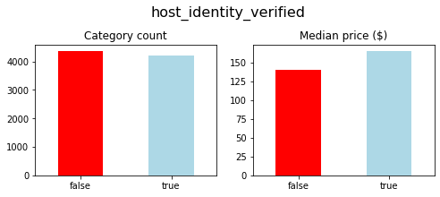

```python
binary_count_price_plot('host_identity_verified')
```

#### Instant Booking

About 42% of properties are instant bookable. However, the added convenience does not seem to have any major effect on the median price per night.

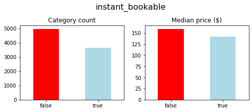

```
0    0.578045
1    0.421955
Name: instant_bookable, dtype: float64
```

```python
binary_count_price_plot('instant_bookable')
print(df.instant_bookable.value_counts(normalize=True))
```